# MCMC Sampling and JAGS

FW8051 Statistics for Ecologists

## Learning objectives

- Gain insights into how MCMC sampling works
- Be able to implement your first Bayesian model in JAGS

Will borrow from…

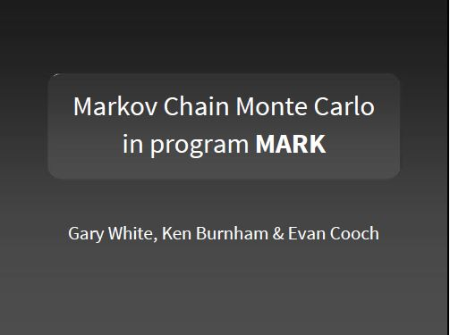

## MCMC

In our moose sighting example, we could determine the posterior distribution using calculus.

In many cases, there will be no closed form solution to:

$$p(\theta | y) = \frac{L(y | \theta)\pi(\theta)}{\int_{-\infty}^{\infty}L(y | \theta)\pi(\theta)}$$

MCMC = Markov Chain Monte Carlo is a way to draw a sequence of random variables that will converge in distribution to $p(\theta | y)$

## MCMC Sampling

Goal: generate samples that we can use to summarize the posterior distribution, $p(\theta | y)$

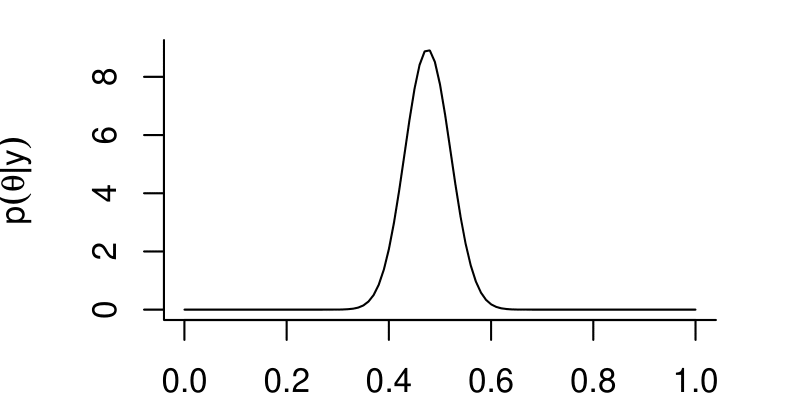

- Once we have these samples, we can estimate $\theta$ by the mean (or median) of the samples.
- We can compute credible intervals using quantiles of the samples.

## Samplers

There are a variety of MCMC algorithms and samplers. We are going to consider 1 approach to gain somegeneral insights into how these methods work.

## Metropolis Algorithm

$$p(\theta | y) = \frac{L(y | \theta)\pi(\theta)}{\int_{-\infty}^{\infty}L(y | \theta)\pi(\theta)}$$

Consider two possible values of $\theta$ = {$\theta_1$ and $\theta_2$}. Without the denominator, we cannot evaluate $p(\theta_1 | y)$ or $p(\theta_2 | y)$.

We can, however, evaluate the relative likelihood of $\theta_1$ and $\theta_2$:

$$\text{R } = \frac{p(\theta_2 | y)}{p(\theta_1 | y)} = \frac{L(y | \theta_2)\pi(\theta_2)}{L(y | \theta_1)\pi(\theta_1)}$$

## Metropolis Algorithm

1. Initiate the Markov chain with an initial starting value, $\theta_0$
2. Generate a new, proposed, value of $\theta$ from a symmetric distribution centered on $\theta_0$ (e.g., $\theta^{\prime}$ = rnorm($\theta_0$, mean =0, sd=1)).
3. Decide whether to accept or reject $\theta^{\prime}$:
   - If R = $\frac{p(\theta^{\prime} | y)}{p(\theta_0 | y)} > 1$: Accept and set $\theta_1 = \theta^{\prime}$!
   - If R $<1$ accept $\theta^{\prime}$ with probability = R. Otherwise (i.e., if reject), set $\theta_1 = \theta_0$
4. Back to step 2, and …

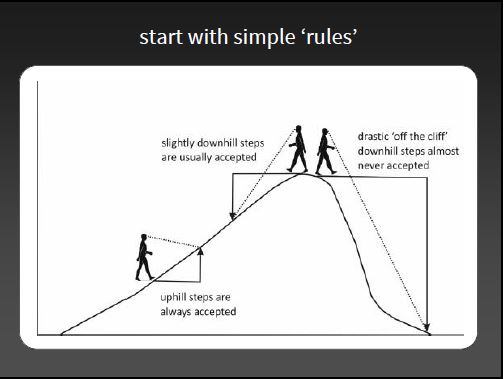

Continue to sample until:

1. The distribution of $\theta_1, \theta_2, \ldots, \theta_M$ appears to have reached a steady state (i.e., reached convergence).
2. The MCMC sample, $\theta_1, \theta_2, \ldots, \theta_M$ is sufficiently large to summarize $p(\theta | data)$

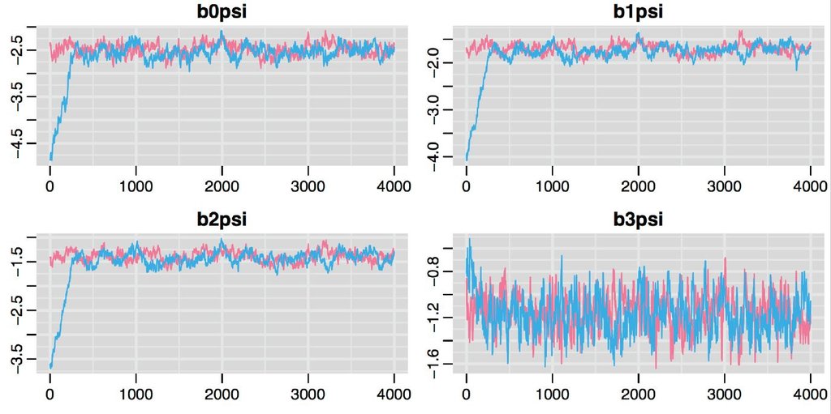

## Convergence

There are no foolproof methods for detecting convergence. Some things that we can and will do:

- Run multiple chains (starting in different places) and see if they converge on similar distributions
- Discard the first $n_{burnin}$ iterations (where the sampler has not yet converged)
- Calculate the Gelman-Rubin Statistic, Rhat = compares variance of between chains to within chains
  - Values near 1 suggest likely convergence
  - Should be less than 1.1 (general rule)

## Details

- With Metropolis or Metropolis-Hastings, need to consider how to generate good proposals
- Other samplers may be more efficient (i.e., reach steady state quicker and better explore the distribution of $p(\theta | data)$)

JAGS will attempt to determine how best to sample once we give it a likelihood and set of prior distributions (one for each parameter).

## JAGS

Steps:

- Specify prior distributions and the likelihood of the data.
- Call JAGS from R to generate samples.
- Evaluate whether or not we think the samples have converged in distribution to $p(\theta | y)$
- Use our samples to characterize the posterior distribution, $p(\theta | data)$

## t-test

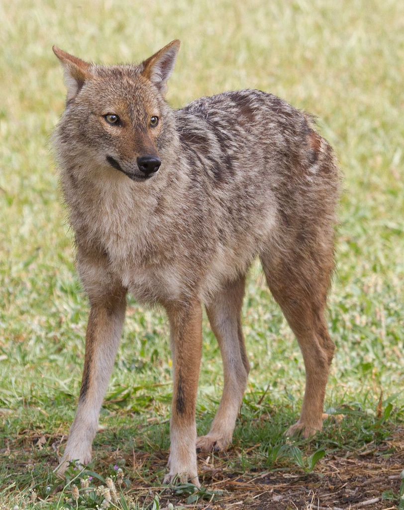

Mandible lengths in mm:

- 10 male and 10 female golden jackals
- From British Museum (Manly 1991)

```r
males<-c(120, 107, 110, 116, 114, 111, 113, 117, 114, 112)
females<-c(110, 111, 107, 108, 110, 105, 107, 106, 111, 111)
```

Do males and females have, on average, different mandible lengths?

$$H_0: \mu_m = \mu_f \text{ versus } H_a: \mu_m \neq \mu_f$$

## JAGS

Likelihood:

- $y_{males} \sim N(\mu_m, \sigma^2)$
- $y_{females} \sim N(\mu_f, \sigma^2)$

Priors:

- $\mu_m \sim N(100, 0.001)$
- $\mu_f \sim N(100, 0.001)$
- $\sigma \sim$ Uniform(0,30)

Notes:

- JAGS and WinBugs represent a normal distribution as $N(\mu, \tau = 1/\sigma^2)$, $\tau$ is called the precision
- Often best to form priors for $\sigma$ (requires thinking about SD rather than 1/variance)

## Where do these priors come from?

Good question. I tried to make sure:

- the priors were dispersed enough to encompass all the likely values for the parameters

It is a good idea to check whether:

- your posterior looks different from your prior (i.e., if it was “informed by the data”)
- the posterior appears to have been constrained by your prior distribution
- your results change if you use a different prior

## JAGS

JAGS/BUGS (hereafter JAGS) code looks just like R code, but with some differences:

- JAGS code is not executed (just defines the model)
- Order does not matter (prior before likelihood, likelihood after prior, etc)

## JAGS

There are 6 types of objects

1. **Modeled data** defined with a $\sim$ (“distributed as”). For example y $\sim$ followed by a probability distribution. The variable y here is the response in our regression model.
2. **Unmodeled data**: objects that are not assigned probability distributions. Examples include predictors, constants, and index variables.
3. **Modeled parameters**: these are given informative “priors” that themselves depend on parameters called hyperparameters. These are what a frequentist would call random effects. We won’t consider till later in the course.
4. **Unmodeled parameters**: these are given uninformative priors. [So in truth all parameters are modeled].
5. **Derived quantities**: these objects are typically defined with the assignment arrow, <-
6. **Looping indexes**: i, j, etc.

## JAGS

Types of objects for JAW example

1. **Modeled data** = males, females
2. **Unmodeled data** = nmales, nfemales
3. **Modeled parameters** (none in this example)
4. **Unmodeled parameters** = mu.male, mu.female, sigma
5. **Derived quantities** = tau, mu.diff
6. **Looping indexes**: i (used twice)

## JAGS Tips

Start simple, then build up.

Lots of good tricks and tips in the Appendix of Kery’s Introduction to WinBugs for Ecologists, especially:

Numbers: 2, 3, 4, 9, 11, 12 (use %T% in JAGS), 14, 16, 17, 20, 23,24, 25, 26, 27

Googling error messages is often useful for diagnosing problems.

## JAGS

Work with `12-BayesMCMC.R` to fit your first model in JAGS